# Central Limit Theorem Simulation

STAT 211

Doug Raffle

This is a simulation of the Central Limit Theorem corresponding to parts of Problem 2 of Homework #7. Keep in mind that your numbers for the population mean and standard deviation will probably be different.

In the problem, we are given that the shipped weights of the bags of chips has a Normal Distribution with mean 16.3 and standard deviation 0.21. We are also told that the printed weight on the bags of chips is 16oz. Formally,

$X \sim N(\mu_x = 16.3, \sigma_x = 0.21)$

We are then given two different sample sizes, $n=5$ and $n=24$ and need to find the sampling distributions of their sample means. Recall:

$\bar{X} \sim N\left(\mu_\bar{x} = \mu_x, \sigma_\bar{x} = \frac{\sigma_x}{\sqrt{n}}\right)$

For this problem, let $\bar{x}_5$ correspond to the means found by sampling with $n=5$ and $\bar{x}_{24}$ correspond to the means found by sampling with $n=24$. In this problem, these refer to a bargain pack of 5 bags and a case of 24 bags, respectively. This gives us the sampling distributions:

$\begin{align} \bar{X}_5 &\sim N\left(\mu_{\bar{x}_5} = 16.3, \sigma_{\bar{x}_5} = 0.0939\right)\\ \bar{X}_{24} &\sim N\left(\mu_{\bar{x}_{24}} = 16.3, \sigma_{\bar{x}_{24}} = 0.0428\right) \end{align}$

These distributions were simulated by first drawing a random sample from a $N(16.3, 0.21)$ distribution of size $500000$ to create a simulated parent distribution.

From here, the first sampling distribution was simulated by taking $500000$ random samples of size $n=5$ where drawn from the parent distribution and the $500000$ sample means calculated.

The sampling distribution for $\bar{x}_{24}$ was simulated in the same fashion.

In summary, what we have are three groups of data:

1. A parent distribution of $500000$ $x$ observations drawn from a $N(16.3, 0.21)$ distribution.
2. A distribution of $500000$ $\bar{x}_5$’s calculated from $500000$ random samples of size $n=5$ from the parent distribution.
3. A distribution of $500000$ $\bar{x}_{24}$’s calculated from $500000$ random samples of size $n=24$ from the parent distribution.

Here, we can see the means and standard deviations of these distributions. Note that they closely approximate the theoretical values.

```
##                                Mean     SD
## Parent Distribution            16.3     0.2098959
## Sampling Distribution (n = 5)  16.2999  0.0936812
## Sampling Distribution (n = 24) 16.30008 0.04300639
```

The histograms of each of these simulated distributions show what happens to the distribution of $\bar{x}$ as we increase $n$. Note the vertical bar representing 16 oz. In particular, notice that as $n$ is increased a much smaller fraction of the values fall to the left of the line.

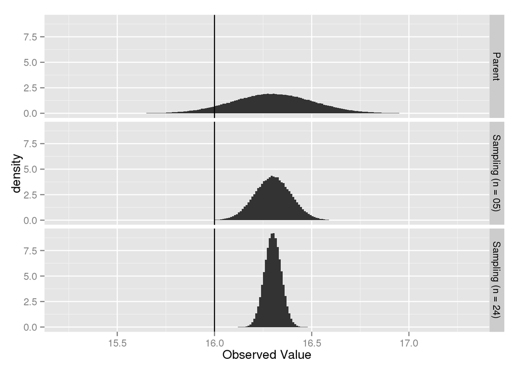

The change in the shapes of the distribution can be seen even more clearly by overlaying density plots of the distributions.

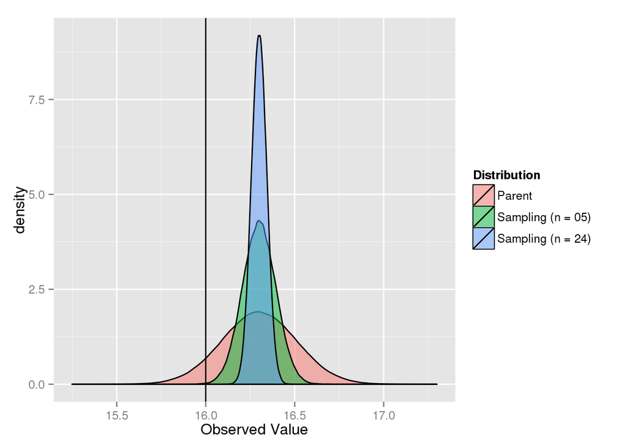